# Question 1: Exploring Risk and Uncertainty

## Does local mirror global?

Figure $\ref{rollcor}$ shows rolling one-year correlations between weekly Capped SWIX returns and the global indexes. Weekly returns are used because the JSE closes before US markets open, which biases daily correlations downward. The correlation with MSCI ACWI averages around 0.68 and rose to roughly 0.9 during the COVID crisis: in a global sell-off, local and global markets move together, exactly when diversification is needed most. More recently the correlation with emerging markets has fallen, suggesting that part of the 2026 volatility is local or EM-specific.

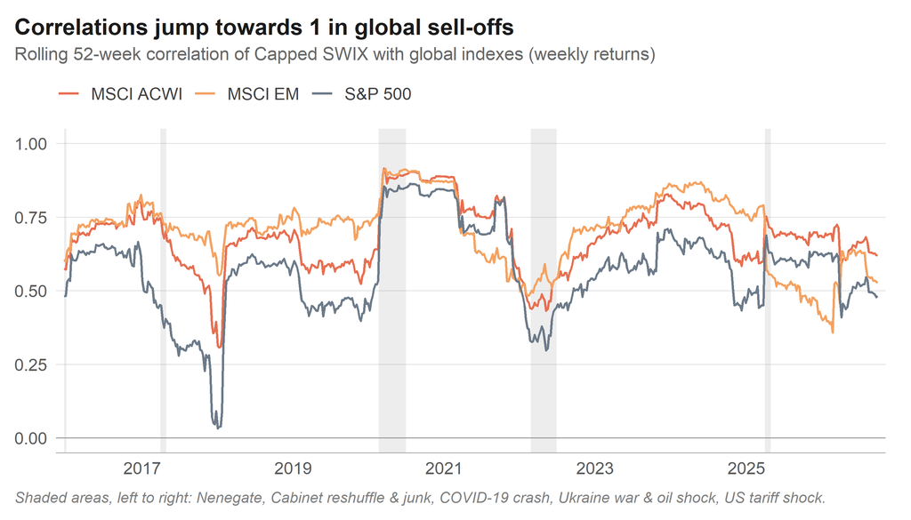

Rolling 52-week correlation of Capped SWIX with global indexes (weekly returns)

## Conditional volatility

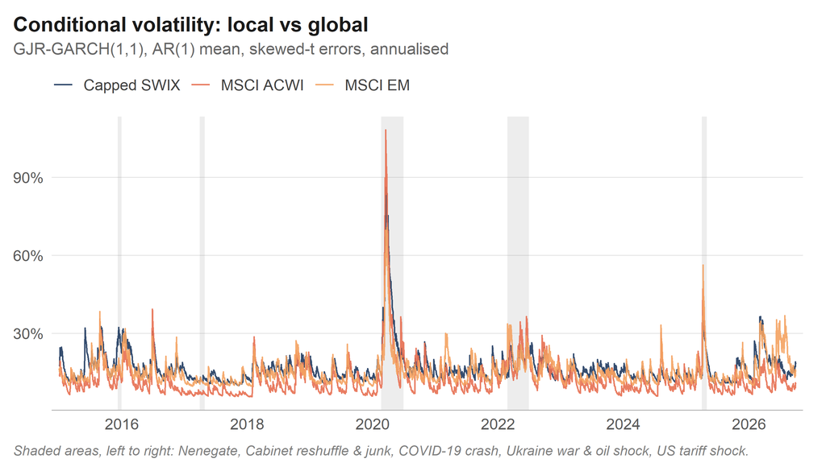

GJR-GARCH conditional volatility, annualised